# Series02-Rstudio :

# 5 Histogram alcohol consumption(glass/week) between snorers and non-snorers

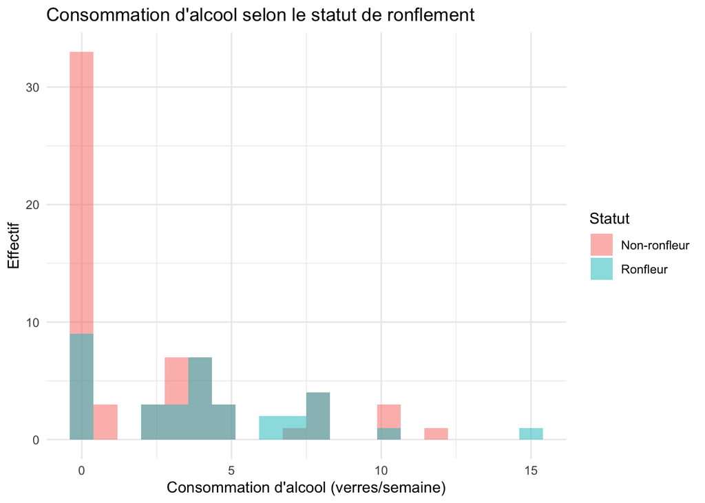

```r
library(ggplot2)
# Plot
ggplot(snore_df, aes(x = alcool, fill = snore)) +
  geom_histogram(position = "identity", bins = 20, alpha = 0.5, na.rm = TRUE) +
  labs(title = "Consommation d'alcool selon le statut de ronflement",
       x = "Consommation d'alcool (verres/semaine)", y = "Effectif", fill = "Statut") +
  theme_minimal()
```

```r
# Test de Wilcoxon
wilcox_test_alcohol <- wilcox.test(alcool ~ snore, data = snore_df, na.rm = TRUE)
wilcox_test_alcohol
```

```
##
##  Wilcoxon rank sum test with continuity correction
##
## data:  alcool by snore
## W = 788, p-value = 0.008594
## alternative hypothesis: true location shift is not equal to 0
```

Are men fatter? # Compare IMC between men and women

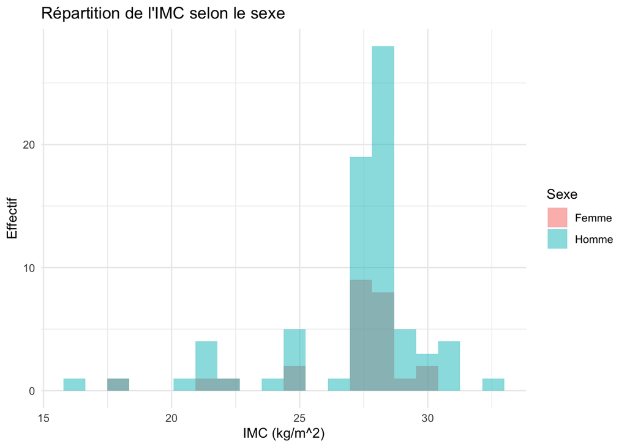

```r
snore_df$gender <- factor(snore_df$sex, levels = c("F","H"),
                         labels = c("Femme","Homme"))
# Plot
library(ggplot2)
ggplot(snore_df, aes(x = IMC, fill = gender)) +
  geom_histogram(position = "identity", bins = 20, alpha = 0.5, na.rm = TRUE) +
  labs(title = "Répartition de l'IMC selon le sexe",
       x = "IMC (kg/m^2)", y = "Effectif", fill = "Sexe") +
  theme_minimal()
```

```r
# Vérifier les niveaux
levels(snore_df$gender)
```

```
## [1] "Femme" "Homme"
```

```r
# Tests de normalité (en retirant les NA)
shapiro_femme <- shapiro.test( snore_df$IMC[snore_df$gender == "Femme"] )
shapiro_homme <- shapiro.test( snore_df$IMC[snore_df$gender == "Homme"] )
# Afficher les résultats dans le knit
shapiro_femme
```

```
##
##  Shapiro-Wilk normality test
##
## data:  snore_df$IMC[snore_df$gender == "Femme"]
## W = 0.71462, p-value = 1.154e-05
```

```r
shapiro_homme
```

```
##
##  Shapiro-Wilk normality test
##
## data:  snore_df$IMC[snore_df$gender == "Homme"]
## W = 0.78184, p-value = 3.456e-09
```

# 6 Since both groups do not follow a normal distribution, we will use a non-parametric test

```r
# Test de Wilcoxon
wilcox_test_IMC <- wilcox.test(IMC ~ gender, data = snore_df, na.rm = TRUE)
wilcox_test_IMC
```

```
##
##  Wilcoxon rank sum test with continuity correction
##
## data:  IMC by gender
## W = 850, p-value = 0.4884
## alternative hypothesis: true location shift is not equal to 0
```

Do women smoke less? # Bar plot for smoking status between men and women

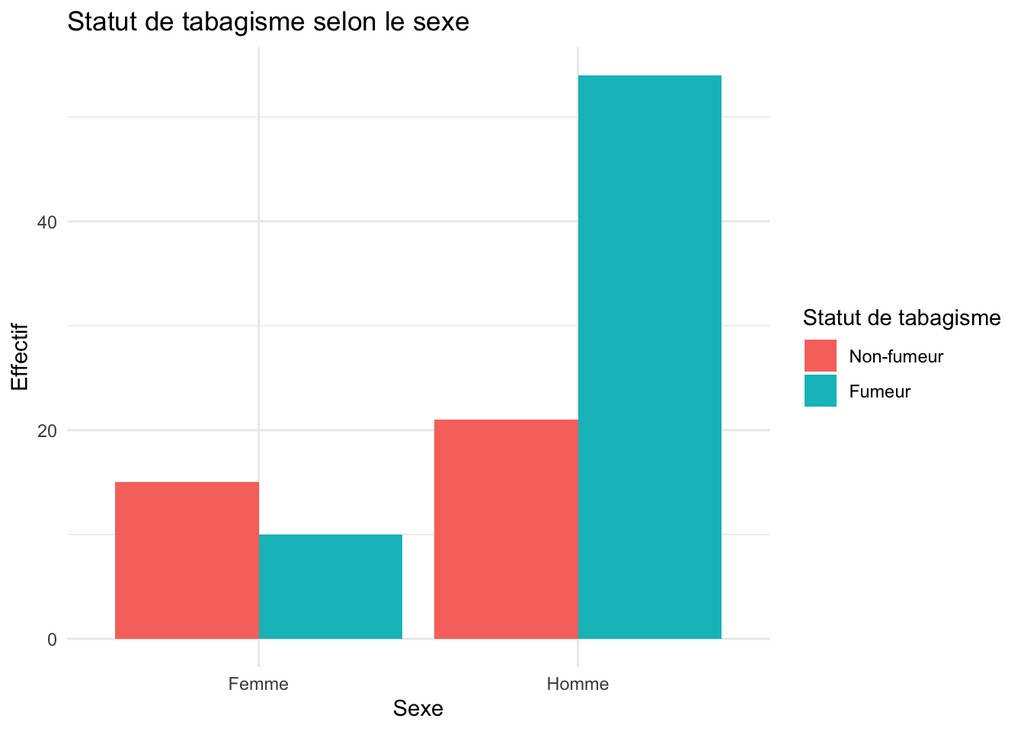

```r
library(ggplot2)
# Ensure 'smoke' is a factor
snore_df$smoke <- factor(snore_df$tabac, levels = c("N","O"),
                         labels = c("Non-fumeur","Fumeur"))
# Plot
ggplot(snore_df, aes(x = gender, fill = smoke)) +
  geom_bar(position = "dodge", na.rm = TRUE) +
  labs(title = "Statut de tabagisme selon le sexe",
       x = "Sexe", y = "Effectif", fill = "Statut de tabagisme") +
  theme_minimal()
```

```r
# Test du Chi
chi2_test_gender <- chisq.test(table(snore_df$gender, snore_df$smoke))
chi2_test_gender
```

```
##
##  Pearson's Chi-squared test with Yates' continuity correction
##
## data:  table(snore_df$gender, snore_df$smoke)
## X-squared = 7.0023, df = 1, p-value = 0.00814
```

From a more general perspective: Are there any correlations between variables?

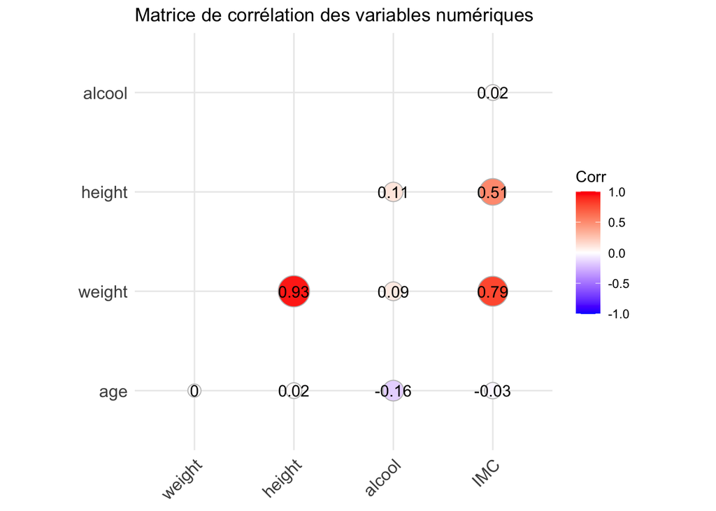

```r
# Select numeric columns for correlation
numeric_cols <- snore_df[sapply(snore_df, is.numeric)]
# Compute correlation matrix
cor_matrix <- cor(numeric_cols, use = "pairwise.complete.obs")
# Load library for visualization
library(ggcorrplot)
# Plot correlation matrix
ggcorrplot(cor_matrix,
           method = "circle",
           type = "lower",
           lab = TRUE,
           title = "Matrice de corrélation des variables numériques")
```

```r
# Write the result of the correlation analysis
cor_matrix
```

```
##                 age       weight     height      alcool         IMC
## age     1.000000000 -0.003976806 0.01938144 -0.15874323 -0.03419517
## weight -0.003976806  1.000000000 0.92697443  0.09150160  0.78811481
## height  0.019381444  0.926974428 1.00000000  0.10635025  0.50605272
## alcool -0.158743225  0.091501597 0.10635025  1.00000000  0.01978898
## IMC    -0.034195168  0.788114808 0.50605272  0.01978898  1.00000000
```

Are there any correlations between variables, including non numeric column (sex “H/F”, tabac “O/N”, snore “O/N”) ?

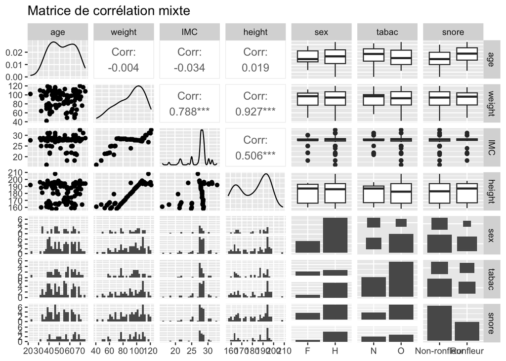

```r
# Load library for mixed correlation
library(GGally)
# Plot mixed correlation matrix
ggpairs(snore_df,
        columns = c("age", "weight", "IMC", "height", "sex", "tabac", "snore"),
        title = "Matrice de corrélation mixte")
```

```r
# Write the result of the correlation analysis
# Note: ggpairs does not provide a correlation matrix output, but visualizes relationships.
```

3 Epilogue: beyond the scope of this series

Finally, some of you may want to go beyond the scope of this series with new questions, such as:

- Can you predict the value of one variable from the others? (linear regression, logistic regression, etc.)
- Can you classify individuals based on their variables? (clustering, PCA, etc.)

NOTE: These questions are more advanced, and I don’t want you to address them from a technical standpoint or provide code. But they give you an idea of what you can do with data mining techniques… provided you know why you want to do it. I invite you to think about the perspective these questions open up and, if you feel ready to do so, to write a short paragraph about it.